# **Impactos das mudanças climáticas: *Mismatches* e alterações na distribuição de plantas e morcegos polinizadores**

Guilherme de Carvalho Chicarolli

Guillermo Florez-Montero

Simone Rodrigues de Freitas

22 de Março de 2021

# Resumo

A modificação na distribuição geográfica das espécies é um dos inúmeros impactos que as alterações no clima podem causar nas comunidades, comprometendo o funcionamento de ecossistemas e interações ecológicas entre indivíduos. Dessa forma, como resposta às mudanças climáticas, as espécies que a adaptarem sua distribuição a lugares mais adequados serão selecionadas evolutivamente, caso contrário serão extintas. Se a adequação não for acompanhada também pela adaptação das outras espécies com os quais há relações ecológicas importantes, pode ocorrer o chamado *mismatch* espacial entre elas, que é dada pela não sobreposição geográfica das espécies. O presente projeto buscou compreender como as mudanças climáticas podem impactar a distribuição geográfica da espécie de quiróptero *Lonchophylla bokermanni* Sazima *et al.*, 1978, e da bromélia *Encholirium subsecundum* (Baker) Mez, duas espécies que possuem relações ecológicas próximas, sendo *L. bokermanni* o único polinizador conhecido de *E. subsecundum*. Utilizando-se de Modelos de Distribuição de Espécies (MDEs) foram criados modelos de distribuição potencial das espécies em dois cenários climáticos projetados para 2050, de RCP 4.5 e 8.5.

> **Palavras chave:** Mudanças climáticas, modelagem, distribuição e sobreposição de espécies.

> **Área do conhecimento:** Ecologia.

# 1. Introdução

# 1. Fundamentação teórica

## 1.1 Mudanças climáticas, alteração na distribuição de espécies e *mismatch* espacial

A distribuição de uma espécie se caracteriza pela área geográfica a qual ela pode ser encontrada (VAN DER PUTTEN, 2012), o que é estabelecido por uma série de fatores determinados pelo nicho ecológico da espécie (BEGON e colab., 2007). Ao serem afetadas por transformações do clima, a população de uma espécie pode ter três desfechos possíveis: adaptação às novas condições, extinção local ou migração para novos ambientes adequados à sobrevivência da espécie (GOROSTIAGUE e colab., 2018; PARMESAN, 2006).

Diversas observações de alterações na distribuição de espécies em paralelo às mudanças climáticas (compreendido aqui principalmente como o aquecimento do clima global) já foram documentadas ao redor do globo (PARMESAN e YOHE, 2003; WALTHER e colab., 2002). Essas alterações podem ter escalas muito distintas entre as espécies, algumas podem ter repostas evolutivas adequadas quanto às mudanças na distribuição devido ao aquecimento do clima (CHEN e colab., 2011), enquanto que outras tendem a não responder de maneira adequada e acabarem extintas localmente (PARMESAN, 2006).

Embora as respostas evolucionárias de alteração na distribuição tenham proporções distintas, observa-se uma tendência de muitas espécies a mudarem suas distribuições em direção altitudes maiores e latitudes polares PARMESAN e YOHE (2003). Nas regiões tropicais, espécies seguem a mesma tendência ao movimento para áreas mais temperadas (PARMESAN, 2006).

Além do mais, tem sido indicado que as mudanças climáticas podem pertubar interações ecológicas entre espécies, podendo levar ao chamado *mismatch* espacial (ruptura ou diminuição das interações ecológicas em razão do desencontro geográfico das espécies) (HEGLAND e colab., 2008; SCHWEIGER e colab., 2008). Pelas respostas evolutivas às mudanças climáticas não acontecerem de formas iguais é que ocorrem os *mismatches*. GOROSTIAGUE e colab. (2018) apontou que as chances que a população de uma espécie tem de colonizar novos habitats depende da possibilidade de que as espécies das quais ela dependa também expandam sua distribuição (*match* espacial com seus parceiros mutualistas), caso o contrário ocorrerá o *mismatch* espacial.

No caso de sistemas ecológicos planta-polinizador, há uma grande preocupação em compreender como as mudanças climáticas podem afetar as distribuições de plantas e seus polinizadores e também os impactos dos *mismatches* sobre os mesmos, tendo em vista a contribuição ambiental desses sistemas e o papel ecológico nos ecossistemas (BEGON e colab., 2007; KEARNS e colab., 1998).

Para as plantas, o *mismatch* com polinizadores efetivos poderia causar a redução da deposição do pólen, aumentando a restrição deste, segundo HEGLAND e colab. (2008). É comum em diversas espécies de plantas a limitação da reprodução devido a polinização insuficiente, conhecido como *Efeito Allee*. Quanto aos polinizadores, pode-se esperar que o desencontro com plantas importantes à alimentação leve a uma redução na quantidade e acesso a alimentos, afetando diretamente sua sobrevivência. HEGLAND e colab. (2008) também discute que os efeitos dos *mismatches* podem ser mais rigoroso aos polinizadores, pois a dependência dos polinizadores na nutrição é maior do que a dependência das plantas que florescem na polinização. Contudo, a força com que espécies de polinizadores são afetados pelos *mismatches* pode depender dos traços funcionais (características fisiológicas, fenológicas e morfológicas) das espécies, como no caso de morcegos polinizadores (ZAMORA-GUTIERREZ e colab., 2021).

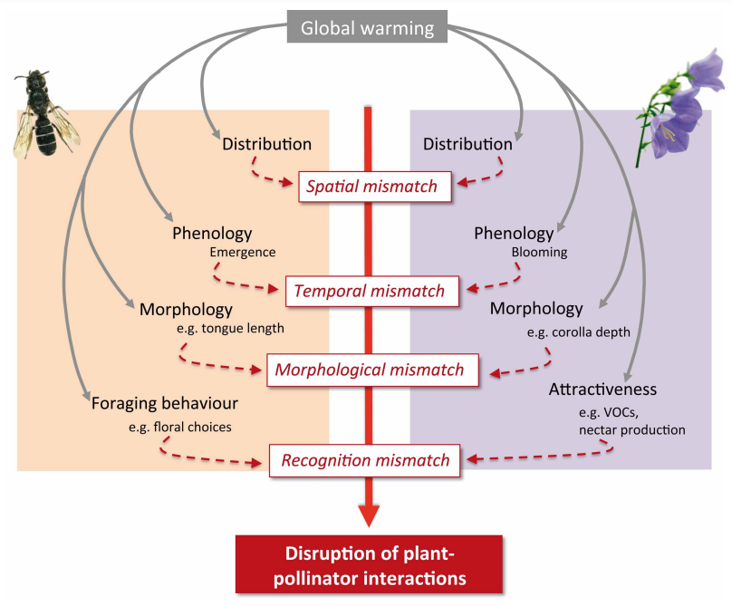

Possíveis impactos dos *mismatches* (espacial, temporal, morfológico e de reconhecimento) nas interações entre plantas e polinizadores. Imagem retirada da fonte: GÉRARD e colab. (2020)

Apesar dos possíveis efeitos negativos causados pelos *mismatches*, algumas características de muitos sistemas planta-polinizador podem agir para minimizar os impactos, como a estrutura aninhada de redes de polinização, na qual um núcleo de espécies generalistas interagem entre si e as espécies especilistas dessa rede interagem apenas com as generalistas (HEGLAND e colab., 2008; JORDANO e colab., 2003). Ademais, há mais espécies generalistas nessas redes do que especialistas, sendo que relações de um único polinizador para uma planta são incomuns, o que pode contribuir para que muitas espécies não sejam afetadas gravemente pelos *mismatches*. Por fim, a maioria das interações de polinização são assimétricas, isto é, caso uma planta seja importante para um polinizador, então a importância desse polinizador para a planta é baixa (HEGLAND e colab., 2008; ZAMORA-GUTIERREZ e colab., 2021).

Por mais que essas propriedades das redes de polinização possam atuar como estabilizadores diante de distúrbios, as redes de polinização ainda podem ser enfraquecidas pelos impactos negativos dos *mismatches*. Tem sido proposto que em sistemas nos quais interações são formadas por generalistas, os polinizadores mostrem maior plasticidade para se adequar às mudanças, enquanto que em sistemas com espécies especialistas exista menor flexibilidade nas respostas, estando portanto mais vulneráveis (MEMMOTT e colab., 2007; RAFFERTY e colab., 2014). Espécies com distribuição restrita também podem ser mais frágeis, ao passo que são mais propícias a perderem habitat e serem extintas do que espécies com distribuições maiores (STAUDE e colab., 2020).

## 1.2 Modelos de Distribuição de Espécies (MDEs)

Os MDEs são ferramentas criadas para a predição da distribuição de espécies ao longo de áreas não amostradas a partir de algoritmos de computação que usam dados de ocorrências (ou ausência) de espécies e dados ambientais. Existem dois tipos principais de Modelos de Distribuição, correlativos e mecanísticos. Enquanto que estes incorporam características fisiológicas das espécies nos modelos, aqueles exploram a associação espacial entre os dados ambientais e de ocorrência da espécie (KEARNEY e colab., 2010).

Diversos algoritmos de modelagem correlativa podem ser encontrados, os quais possuem diferentes tratamentos matemáticos e computacionais para os dados recebidos, mas de maneira simplificada, os algoritmos dos MDEs recebem como *input* do usuário os registros de localidades de uma dada espécie (a distribuição observada) e as camadas ambientais (mais comumente dados climáticos de temperatura e precipitação) preditoras da distribuição da espécie. Assim, o algoritmo utiliza a distribuição observada como uma função de condições ambientais para criar um modelo de distribuição da espécie que avalia quais características de habitat são importantes à espécie, diante dos dados de treino (ELITH e LEATHWICK, 2009). O modelo pode ser então aplicado para tempos climáticos do presente ou outros, gerando como *output* os mapas com as predições da distribuição potencial para a espécie (ELITH e LEATHWICK, 2009; MILLER, 2010).

Os MDEs desempenham papel importante para a identificação de áreas potenciais à conservação, com risco de propagação de vetores de doenças, potenciais espécies invasoras etc (LÓPEZ-ARÉVALO e colab., 2011; MILLER, 2010). Porém com a crescente preocupação com o impacto das mudanças climáticas, os MDEs tornaram-se essenciais para compreender a resposta de espécie e comunidades à alterações futuras no clima global.

Quanto ao *mismatch* espacial e sobreposição da distribuição de espécies, MDEs são instrumentos que podem prover estimativas confiáveis da distribuição futura de espécies que possuem interações ecológicas, auxiliando a avaliar o potencial de *mismatch* espacial. (GOROSTIAGUE e colab., 2018) buscou compreender os possíveis impactos das mudanças climáticas em 11 espécies de cacto dos Andes e o sobreposição espacial com seus respectivos polinizadores através de modelos correlativos de distribuição, estimando contração na distribuição das espécies no futuro, porém diminuição no *mismatch* espacial entre elas. (GÓMEZ-RUIZ e LACHER JR., 2019) também utilizou da modelagem de distribuição para avaliar a sobreposição potencial de espécies de *Agave* e seus morcegos polinizadores no presente e em projeções futuras, encontrando uma diminuição da sobreposição entre as espécies.

# 2. Materiais e métodos

## 2.1 Espécies

Modelamos a distribuição de 2 espécies: a de quiróptero *Lonchophylla bokermanni* Sazima *et al.*, 1978, e de bromélia *Encholirium subsecundum* (Baker) Mez.

*L. bokermanni* Sazima *et al.*, 1978 (DIAS e colab., 2013; SAZIMA e colab., 1978) é uma espécie de morcego de porte médio endêmica do Brasil, fazendo parte do gênero *Lonchophylla* (família Phyllostomidae), que abrange espécies nectarívoras, com focinho alongado e língua comprida (FLEMING e colab., 2009). Com poucas ocorrências no bioma do Cerrado e da Caatiga, em Minas Gerais e Bahia (tabela 2), o quiróptero possui uma distribuição restrita (CLÁUDIO e colab., 2018). Ainda pouco se conhece sobre a biologia da espécie, porém sabe-se que alimenta-se de pólen, néctar e insetos (DIAS e colab., 2013; MORATELLI, 2013).

Em razão da degradação de seus habitats, a classificação de *L. bokermanni* quanto ao seu grau de ameaça está como “Em perigo” de acordo com a Listade Espécies Ameaçadas da União Internacional para a Conservação da Natureza (IUCN) (CLÁUDIO e colab., 2018) e como “Quase ameaçada” pelo Instituto Chico Mendes de Conservação da Biodiversidade (ICMBio) (Livro Vermelho da Fauna Brasileira Ameaçada de Extinção, 2018).

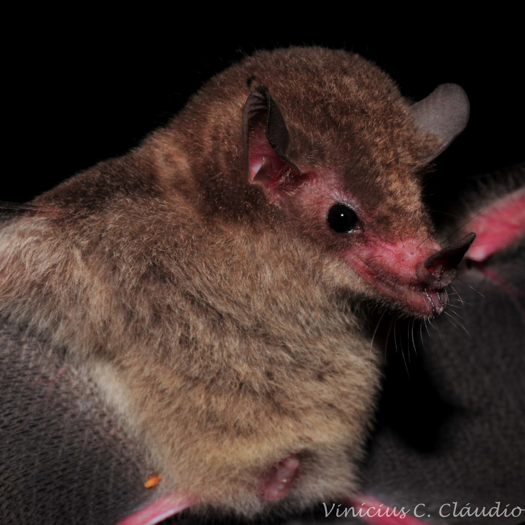

*Lonchophylla bokermanni* Sazima *et al.*, 1978. Imagem retirada da fonte: CLÁUDIO e colab. (2018)

*Encholiirum subsecundum* (Baker) Mez é uma espécie de bromélia do gênero *Encholirium* (família Bromeliaceae) que ocorre em formações rochosas, podendo atingir até 2 metros de altura e com um padrão floral quiropterófilo (CAVALLARI, 2004; DIAS e colab., 2013). A espécie é endêmica do Brasil, com ocorrências nos biomas da Caatinga, Mata Atlântica e, principalmente, no Cerrado (CAVALLARI, 2004; FORZZA, 2005; SAZIMA e colab., 1989), nos estados de Minas Gerais e Bahia (tabela 1). Embora existam outras espécies de morcegos nectarívoros na área de ocorrência de *E. subsecundum*, *L. bokermanni* é o único polinizador conhecido da bromélia (SAZIMA e colab., 1989). *E. subsecundum* não se encontra no Livro Vermelho da Flora do Brasil (MARTINELLI e MORAES, 2013) ou na Lista Vermelha da IUCN (“The IUCN Red List of Threatened Species”, 2021).

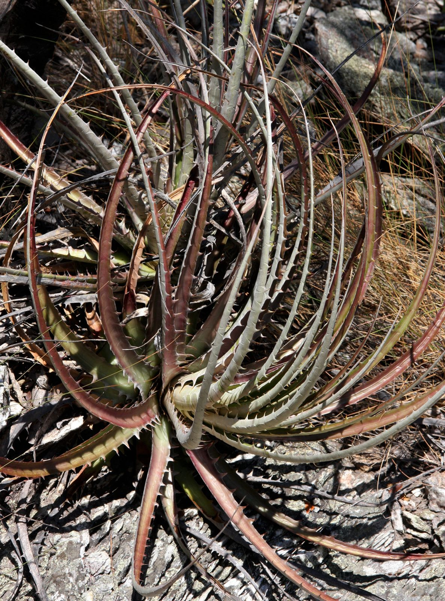

*Encholirium subsecundum* (Baker) Mez. Imagem de: N. Taylor & D. Zappi

## 2.2 Ocorrências

Para o processo de Modelagem de Distribuição são necessários registros georreferenciados das espécies. Assim, foram coletados os registros de ocorrências de *Encholirium subsecundum* e *Lonchophylla bokermanni* em 3 bancos de registros onlines: Specielink, GBIF e SiBBr, que reunem registros de coleções de espécies. Também foram utilizados registros de artigos que fizeram coletas de espécies.

Foram reunidos 24 registros ao todo da espécie *L. bokermanni*, com o único parâmetro prévio de possuírem coordenadas georreferenciadas. Em seguida, os registros com coordenadas geográficas duplicadas foram retirados da base de dados, sobrando apenas uma ocorrências entre as duplicadas. Então, um *buffer* com raio de 5 km foi criado ao redor de cada registro e foram selecionados apenas uma ocorrência dentro de cada *buffer*, a fim de diminuir o viés amostral na seleção de ocorrências pelo modelo (HIJMANS e SPOONER, 2001). Por fim, sobraram 8 registros, os quais foram utilizados para as modelagens (tabela 2).

Todos as ocorrências restantes tiveram a descrição de município e localidades dos registros confrontados com os pontos de georreferenciamento (latitude e longitude), com o objetivo de verificar se estavam de acordo. Nenhum registro restante possuía descrição de localidade que não estivesse de acordo com a posição geográfica descrita.

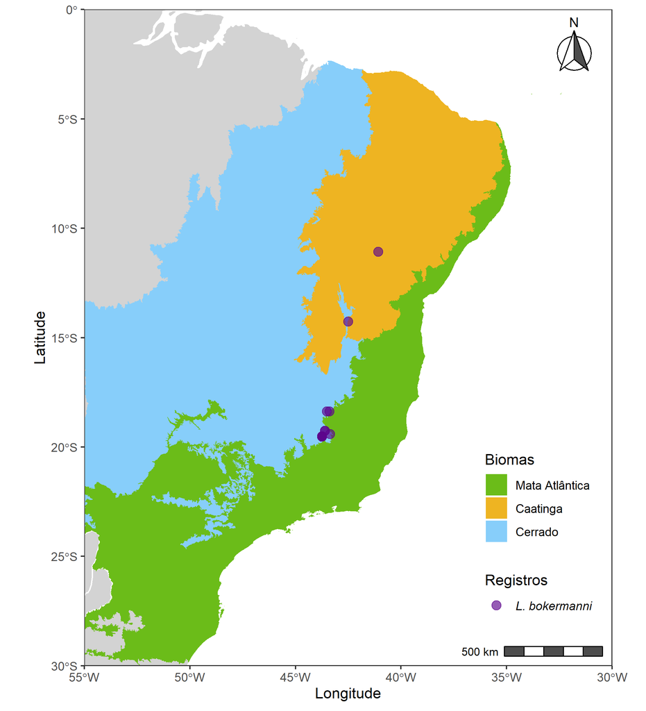

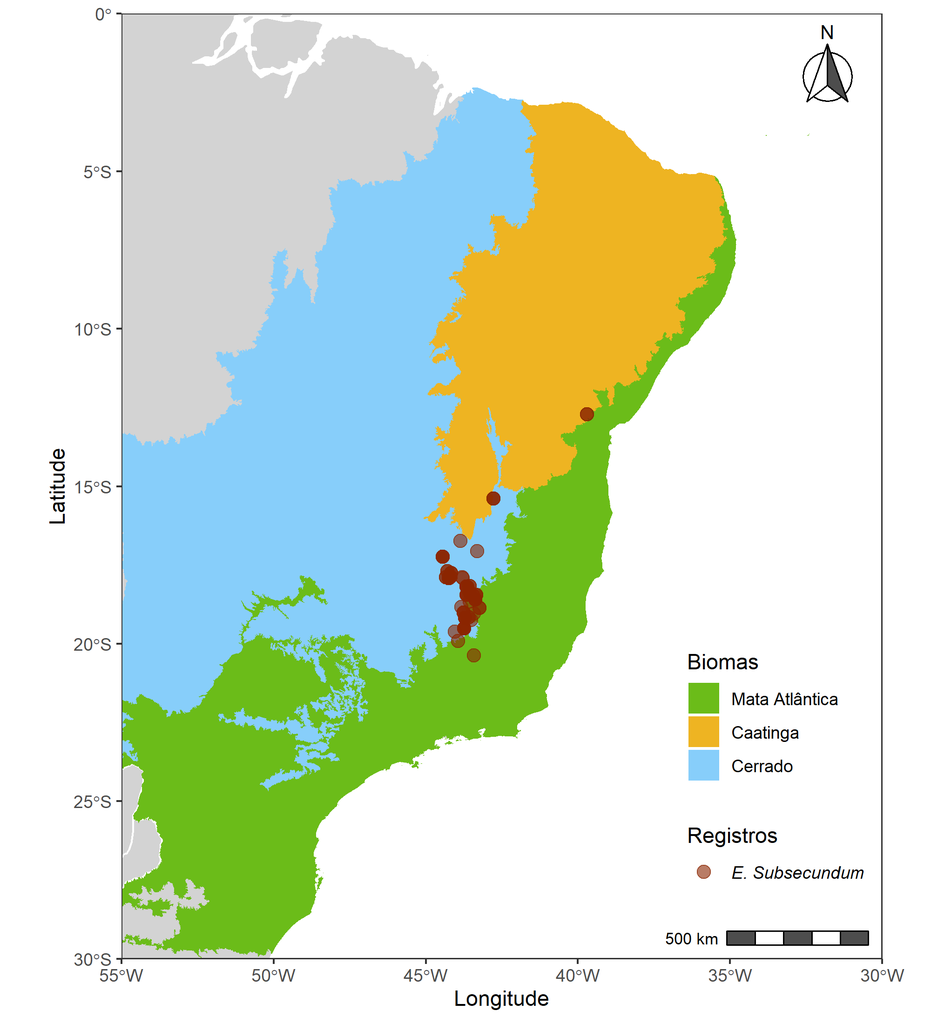

Gráfico das localidades de L. bokermanni (à esquerda) e E. subsecundum (à direita).

## 2.3 Dados ambientais

Para produzir os modelos de distribuição potencial das espécies utilizamos camadas ambientais obtidas do projeto WorldClim (FICK e HIJMANS, 2017), com resolução espacial de 2.5 arc-minutos (aproximadamente 4.5 km no equador) e representando o clima atual, correspondendo à média das observações de 1970 a 2000. As 19 variáveis bioclimáticas (tabela 3) derivam de dados de temperatura e precipitação, repesentando tendências anuais, condições extremas e sazionalidade (FICK e HIJMANS, 2017).

Para as predições de distribuições futuras, utilizamos camadas projetadas do clima global para o ano de 2050 (média de 2041 a 2060) de acordo com o Quinto Relatório de Avaliação do Painel Intergovernamental sobre Mudanças Climáticas (AR5) do Painel Intergovernamental sobre Mudanças Climáticas (IPCC, 2013), obtidas também através do projeto WorldClim (FICK e HIJMANS, 2017). São camadas de 19 biovariáveis (tabela 3) projetadas para o futuro, com resolução de 2.5 arc-minutos e usando o modelo de circulação CNRM-CM5, do laboratório francês *Centre National de Recherches Meteorologiques*, representando dois cenários distintos de emissão de gases do efeito estufa conforme o *Representative Concentration Pathways* (RCPs), o de RCP 45 (cenário no qual as emissões de $CO_2$ começam a diminuir a partir de 2045) e de RCP 85 (as emissões de gases continuam a crescer ao longo do século 21) (VUUREN e colab., 2011).

Diversos autores apontaram problemas de multicolinearidade de variáveis climáticas em modelagens de distribuição (BRAUNISCH e colab., 2013; CRUZ-CÁRDENAS e colab., 2014), afetando diretamente os resultados e performance dos modelos. A fim de avaliar a gravidade da colinearidade entre os pontos de ocorrências das duas espécies e o conjunto de biovariáveis do clima atual, medimos o Fator de Inflação da Variância (VIF) das camadas ambientais. Para os dados de ocorrência da planta *E. subsecundum*, o teste resultou em 12 (de 19) variáveis bioclimáticas com problemas de colinearidade (tabela 4). Enquanto que para o morcego *L. bokermanni*, 17 variáveis apresentaram alto grau de colinearidade (tabela 5). Valores de VIF maiores que o limiar 10 já indicam problema de colinearidade.

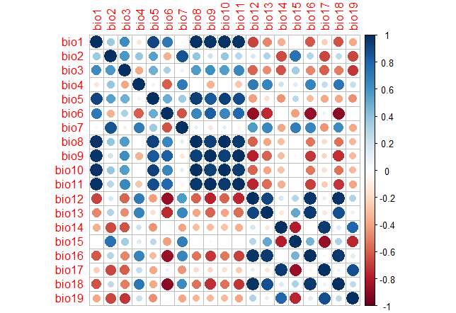

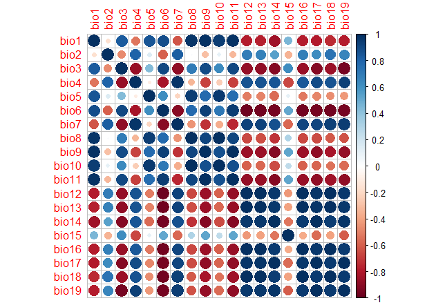

Matriz de correlação entre as variáveis bioclimáticas para a espécie E. subsecundum (à esquerda) e L. bokermanni (à direita)

## 2.4 Modelo de Distribuição Potencial

Para o processo de modelagem foi utilizado o pacote SDM (*Species Distribution Modelling*) (NAIMI e ARAÚJO, 2016), (versão 1.0-89), da linguagem de programação R (R CORE TEAM, 2021), versão 4.1.1, por apresentar uma série de funções importantes que automatizam o processo de modelagem, além de conter diversos algoritmos de modelagem.

Nós usamos o algoritimo correlativo de modelagem de distribuição Maxent (*Maximum Entropy*) (PHILLIPS e colab., 2006), versão 3.4.4, disponível no pacote SDM. Maxent é um *software*, de uso livre, para a modelagem da distribuição potencial de espécies a partir da técnica de *machine learning* conhecida como *maximum entropy modeling*.

Maxent recebe como *input* as ocorrências georreferenciadas da espécie e o conjunto de dados camadas ambientais (variáveis preditoras) determinados pelo usuário e dividido em *grid cells* ao longo de uma região escolhida (MEROW e colab., 2013). Diante disso, o algoritmo amostra uma quantidade de localizações de *background* das camadas ambientais, que são confrontadas com as localizações geográficas da espécie, gerando como *output* um modelo que traduz a probabilidade de distribuição da espécie para cada *grid cell*, dada a aptidão às condições ambientais preditas para a espécie. Maxent procura, assim, a distribuição mais espalhada (de entropia máxima) para a espécie na região de estudo.

O algoritmo foi escolhido devido a sua performance superior a outros quando utilizado quantidades pequenas de dados de ocorrência das espécies (HERNANDEZ e colab., 2006; WISZ e colab., 2008), crucial para nós devido a quantidade pequena de dados para a espécie de morcego *L. bokermanni*. Além disso, Maxent requer apenas ocorrências de presença das espécies, excluindo a necessidade de registros de ausência e facilitando o trabalho com espécies que possuem baixa quantidade de registros ou não possuam registros de ausência.

Como parâmetros de modelagem para o Maxent, utilizamos regularização igual a 1 e prevalência de 50%, ambos valores padrão. O parâmetro de extrapolação e *clamping* foram permitidos para gerar predições além da distribuição presente das espécies. Para cada espécie foram geradas 50 replicações, metade usando o método de validação por *bootstrap* e a outra metade por subamostragem. 70% dos registros de ocorrência foram separados e utilizados para treino e 30% para o teste dos modelos. 10 mil pontos de *background* foram gerados aleatoriamente ao longo de cada camada ambiental, os quais foram usados para a modelagem como amostras das variáveis ambientais. Foram utilizados parâmetros padrão para a modelagem devido à falta de informação sobre o habitat e capacidade de dispersão das espécies modeladas. Para gerar um modelo consenso dentre as 50 replicações, usamos a média ponderada das área de distribuição das replicações.

Fizemos uma modelagem prévia para cada espécie com os parâmetros mencionados e todas as variáveis ambientais. A partir de então, as quatro camadas ambientais com maior importância para os modelos (gráficos 6 e 7), de acordo com o AUC, foram selecionadas e separadas. A variável com maior valor VIF e menor importância dentre as quatros selecionadas foi retirada e as três camadas restantes foram utilizadas em uma nova modelagem final, com os parâmetros apresentados no parágrafo anterior, que gerou as projeções dos modelos.

A fim de avaliar a performance dos modelos criados pelo Maxent, foi empregado o AUC (*Area Under the Curve*) parcial da curva ROC (*Receiver Operating Characteristic Curve*) (PHILLIPS e colab., 2006), obtido ao plotar valores de sensitividade no eixo y e 1-especificidade no eixo x e com valores variando de 0 (modelo com 100% de taxa de erro) a 1 (modelo totalmente em acordo com a distribuição observada). O AUC é uma medida estatística independente da escolha do limiar (*threshold*) e tornou-se muito popular para esimar a performance de modelos de distribuição. O valor de limiar para os modelos de cada espécie foi obtido a partir da maximização da especificidade mais a sensitividade (LIU e colab., 2013), o qual é independente da quantidade de pseudo-ausências, o que pode ser vantajoso ao se utilizar pequenas quantidade de dados. Com o limiar é possível converter os mapas de adequabilidade das espécies para mapas binários (presença-ausência).

O modelo de cada espécie foi então projetado para os cenários futuros, de RCP 4.5 e 8.5, e para o presente gerando como saída 6 mapas de distribuição potencial, 3 da planta e 3 do morcego. Foram então elaborados 5 mapas finais para cada espécie: 3 que mostram as distribuições nos cenários e 2 com as alterações nas distribuições com respeito ao presente. Criamos também 3 mapas com as sobreposições entre as distribuições das espécies nos três cenários distrintos.

## 2.5 Estimativa da sobreposição e *mismatch* espacial

Seguindo o método apresentado por GOROSTIAGUE e colab. (2018), para o cálculo dos potenciais impactos das mudanças climáticas na distribuição espacial das espécies utilizamos uma variável da alteração na distribuição nos cenários futuros em relação à distribuição potencial no presente. Também estimamos a distribuição compartilhada (sobreposta) entre a planta e o morcego e então calculamos a diferença entre essa área nos cenários futuros com respeito ao presente. A distribuição compartilhada representa a área de encontro entre o morcego polinizador e a planta (*spatially matched range*), assumindo que o morcego é efetivo e sua presença já garante a polinização da planta.

A taxa de correspondência espacial (*spatial match*) foi calculada como a diferença entre a distribuição potencial de cada espécie e a distribuição não compartilhada. A índice de *mismatch* é a taxa de correspondência espacial subtraída de 100. Valores de *mismatch* abaixo de 20% foram considerados baixos, isto é, menos de 20% da distribuição de uma espécie não está sobreposta com a distribuição da outra (GOROSTIAGUE e colab., 2018).

## 2.6 Etapas do projeto

O projeto segue as etapas para Modelagem de Distribuição de Espécie propostas por PINAYA (2013), organizada em 5 etapas: 1. Construção da hipótese científica; 2. Pré-análise dos dados; 3. Modelagem; 4. Predição e 5. Validação da hipótese científica.

1. Construção da hipótese científica: foi definida a proposta do projeto, assim como os objetivos e hipóteses científicas a serem testadas.
2. Pré-análise dos dados: foram coletados os dados de ocorrência das espécies (descrito na seção 2.2) de banco de registros online e artigos (tabela 1 e 2), os registros foram então tratados. Nesta etapa, também foram obtidos as variáveis ambientais bioclimáticas para o uso na modelagem (descrito na seção 2.3). Os dados obtidos foram analisados a fim de verificar a viabilidade de utilizá-los.
3. Modelagem: diante dos dados obtidos, foi escolhido o algoritmo mais adequado para a modelagem de distribuição potencial (seção 2.4). As variáveis ambientais preditoras foram então selecionadas por meio de uma modelagem prévia para cada espécie, utilizando o algoritmo Maxent. Após selecionar as três camadas preditoras foi obtido um modelo final para cada espécie, o qual teve sua performance avaliada.
4. Predição: o modelo criado na etapa anterior foi utilizado para projetar a distribuição das espécies para o cenário climático presente e os do futuro, de RCP 4.5 e 8.5.
5. Validação da hipoótese científica: foram analisados os conjuntos de dados gerados pelos modelos de distribuição (ver resultados), gerando os mapas de predição. A partir de então foi possível confrontá-los com as hipóteses propostas inicialmente.

## 2.7 Repositório dos códigos e dados

Todos os dados e códigos utilizados no projeto, desde a obtenção e limpeza dos dados de ocorrência à elaboração dos mapas, estão disponíveis na plataforma online de hospedagem de códigos GitHub em https://github.com/guilhermechicarolli/PDPD, podendo ser baixados e reproduzidos.

# Resultados

O algoritmo Maxent demonstrou boa performance preditiva, obtendo altos valores médios de AUC (gráficos 8 e 9). A proporção de área potencial ganha e perdida sob os diferentes cenários climáticos com relação ao presente variou entre ambas as espécies (tabela 6), todas apresentaram contração na área ambiental adequada nos cenários futuros de mudanças climáticas.

Os modelos previram redução de 36.98% de áreas adequadas (com respeito à área presente) para *Lonchophylla bokermanni* no cenário de RCP 4.5 para o ano de 2050 e diminuição de 58.06% de área para o panorama de RCP 8.5, para 2050 (tabela 7). A mesma tendência foi observada para *Encholirium subsecundum*, a qual previmos encolhimento de 72.70% de área apropriada (relativa à área do presente) para o futuro de RCP 4.5 (2050), enquanto que no cenário de RCP 8.5 a redução na área é de 81.11% (com respeito ao presente).

Previmos uma diminuição na área de sobreposição potencial entre a distribuição de ambas as espécies (planta+morcego), a qual diminui 67.76% no cenário de RCP 4.5 e 79.86% no RCP 8.5, em relação à sobreposição no presente (tabela 8). A taxa de *mismatch* espacial (desencontro geográfico) entre a planta e o morcego aumentou com relação à distribuição de *Lonchophylla bokermanni*, que apresentou 26.07% de sua distribuição potencial presente sem sobreposição com a da planta, no cenário de RCP 4.5, 61.56% da área do morcego não apresentou sobreposição e no RCP 8.5, 63.07% de sua área. Em contrapartida, observamos diminuição na taxa de *mismatch* para a planta, previmos 28.06% de sua área presente não tenha sobreposiçãp com a distribuição do morcego, 15.07% da área no futuro RCP 4.5 sem sobreposição e 23.30% da área no RCP 8.5 (tabela 9).

# Conclusão

Nós desenvolvemos modelos correlativos com base unicamente em variáveis bioclimáticas, afim de uma primeira tentativa de acesso aproximado aos impactos potenciais das mudanças climáticas na distribuição da espécie de quiróptero *Lonchophylla bokermanni* Sazima *et al.*, 1978, e seu parceiro mutualista, a bromélia *Encholirium subsecundum* (Baker) Mez.

Os modelos para ambas as espécies mostraram que sob os dois cenários climáticos futuros (ano de 2050), é esperado redução de ambientes adequados, o que aumenta ainda mais sob o RCP (*Respresentative Concentration Pathway*) 8.5, o mais extremo. *E. subsecundum* apresentou as alterações mais severas em sua distribuição, chegando a perder até 81% de área potencial sob o cenário de RCP 8.5, em relação à área do presente (figura 15). *L. bokermanni* também teve sua distribuição potencial afetada de maneira aguda, perdendo até 58% de sua área potencial original no RCP 8.5 (figura 20). A maior perda de habitat sob o cenário pessimista sugere menor tolerância das espécies às mudanças climáticas mais intensas, além de ambas demonstarem a tendência de contrair suas distribuições em direção ao bioma da Mata Atlântica.

Nos RCPs futuros, ambas as espécies apresentaram perda significativa de distribuição potencial nos biomas do Cerrado e da Caatinga (figuras 14, 15, 19 e 20). A aptidão à perda de habitat no Cerrado pelas espécies é plausível a medida em que o bioma é ameaçado devido a processos antrópicos de uso exploratório do solo, desmatamento e queimadas (FILHO e COSTA, 2016; INPE, 2021). A situação de degradação de ambientes ainda é prevista a continuar em cenários futuros, intensificando períodos de seca e impactando o ciclo hidrológico no Cerrado (ARANTES e colab., 2016; PBMC, 2014; SIQUEIRA e PETERSON, 2003).

A área de sobreposição espacial potencial entre ambas as espécies também apresentou a propensão de contração nos cenários futuros, perdendo quase 80% da área de sobreposição com respeito ao presente, sob o cenário de RCP 8.5 (figura 6). Porém, a relação entre a sobreposição e a distribuição potencial é distinta entre ambas as espécies. *L. bokermanni* mostrou diminuição na taxa de sobreposição com relação à sua distribuição nos cenários futuros, obtendo apenas 36.9% de sobreposição espacial com a planta no cenário de RCP 8.5 (tabelas 8 e 9). Nos dois cenários climáticos futuros analisados, os modelos mostraram que mais de 60% da distribuição potencial do morcego não possuía correspondência espacial com a planta, caracterizando o *mismatch* espacial (HEGLAND e colab., 2008; SCHWEIGER e colab., 2008) por parte do morcego.

Em contrapartida, *E. subsecundum* apresentou aumento na taxa de sobreposição em relação a sua distribuição nos cenários futuros (tabelas 8 e 9), chegando a uma alta porcentagem de 84.9% de sobreposição sob RCP 4.5, o que implica que apenas 15% de sua distribuição potencial nesse cenário está em desencontro geográfico com o morcego. No RCP 8.5, o desencontro espacial cresce para 23.3% da área potencial da planta. Os resultados apontam portanto a possibilidade de não ocorrer o *mismatch* espacial com respeito à distribuição da planta, a qual pode chegar a aumentar a sobreposição com o morcego.

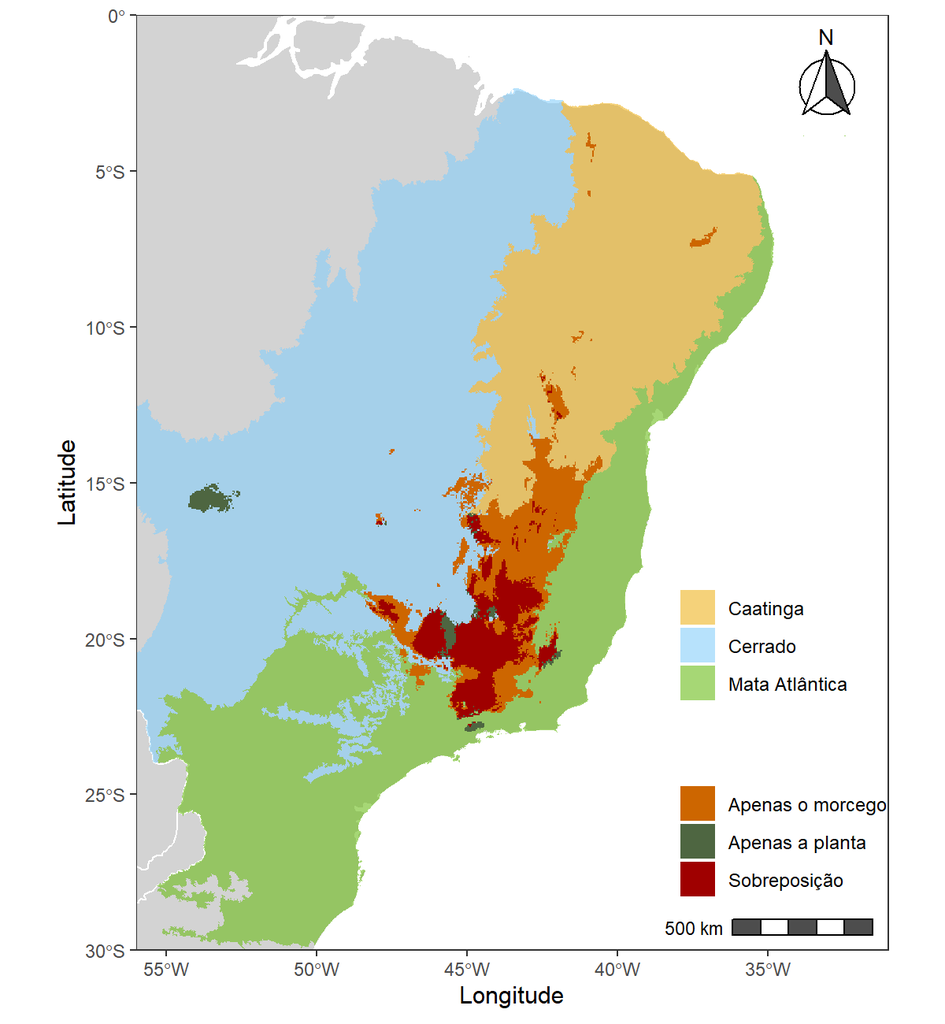

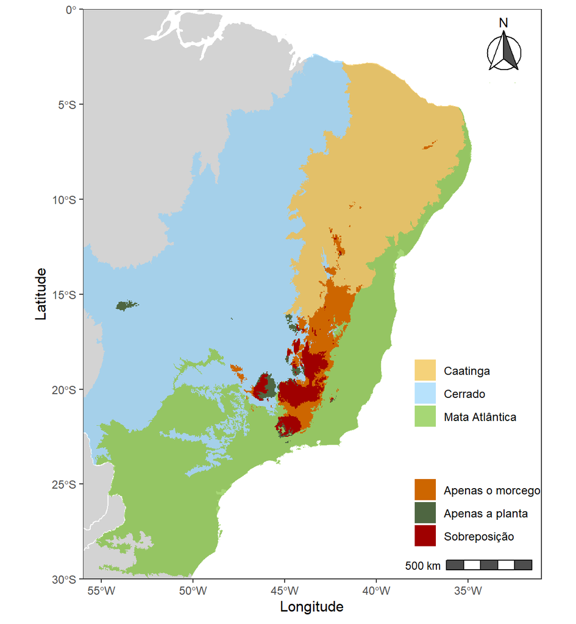

Mapas de sobreposição entre as distribuições da planta e do morcego no RCP 4.5 (acima) e RCP 8.5 (abaixo).

# Apêndice

## Tabelas

**Tabela 1:** Pontos de ocorrências de *Encholirium subsecundum* (Barker Mez).

| Estado | Município | Longitude | Latitude | Referência |
| --- | --- | --- | --- | --- |
| Minas Gerais | Belo Horizonte | -43.93780 | -19.92080 | Fundação Zoo-Botânica de Belo Horizonte |
| Minas Gerais | Santana do Riacho | -43.71440 | -19.16890 | Fundação Zoo-Botânica de Belo Horizonte |
| Minas Gerais | Conceição do Mato Dentro | -43.42500 | -19.03720 | Fundação Zoo-Botânica de Belo Horizonte |
| Minas Gerais | Serro | -43.37940 | -18.60470 | Coleção da Escola Superior de Agronomia Luiz de Queiroz - USP |
| Minas Gerais | Serro | -43.44500 | -18.47250 | Herbário do Museu Nacional |
| Minas Gerais | Jequitaí | -44.44560 | -17.23560 | Coleção da Universidade Federal de Viçosa |
| Minas Gerais | Buenópolis | -44.18000 | -17.87330 | Coleção da Universidade Federal de Viçosa |
| Minas Gerais | Buenópolis | -44.23389 | -17.92389 | Coleção da Universidade Federal do Maranhão |
| Minas Gerais | Buenópolis | -44.24944 | -17.90917 | Coleção da Universidade Federal do Maranhão |
| Minas Gerais | Santana do Riacho | -43.71440 | -19.16890 | Coleção da Universidade Federal de Viçosa |
| Minas Gerais | Mariana | -43.41610 | -20.37780 | Coleção da Universidade Federal de Viçosa |
| Minas Gerais | Datas | -43.65580 | -18.44560 | Herbário do Museu Botânico Municipal |
| Minas Gerais | Joaquim Felício | -44.17220 | -17.75750 | Coleção da Universidade Estadual de Feira de Santana |
| Minas Gerais | Joaquim Felício | -44.29190 | -17.69890 | The New York Botanical Garden |
| Minas Gerais | Joaquim Felício | -44.17220 | -17.75750 | Herbário da Universidade Estadual de Feira de Santana |
| Minas Gerais | Santana do Riacho | -43.71440 | -19.16890 | Instituto de Botânica |
| Minas Gerais | Penha da França | -43.83333 | -18.83333 | Coleção da Universidade de Brasília |
| Minas Gerais | Montes Claros | -43.86170 | -16.73500 | Coleção da UNICAMP |
| Minas Gerais | Santo Antônio do Itambé | -43.33944 | -18.45694 | Herbário da UFMG |
| Minas Gerais | Pedro Leopoldo | -44.04310 | -19.61810 | Herbário da UFMG |
| Minas Gerais | Itacambira | -43.30890 | -17.06470 | Herbário da UFMG |
| Minas Gerais | Dom Joaquim | -43.23333 | -18.86667 | Herbário do Museu do Jardim Botânico do Rio de Janeiro |
| Minas Gerais | Mato Verde | -42.77889 | -15.38667 | Herbário do Museu do Jardim Botânico do Rio de Janeiro |
| Minas Gerais | Santana de Pirapama | -43.75556 | -19.00611 | Herbário do Museu do Jardim Botânico do Rio de Janeiro |
| Minas Gerais | Diamantina | -43.55278 | -18.35500 | Herbário do Museu do Jardim Botânico do Rio de Janeiro |
| Minas Gerais | Diamantina | -43.62806 | -18.19194 | Herbário do Museu do Jardim Botânico do Rio de Janeiro |
| Minas Gerais | Presidente Kubitschek | -43.55722 | -18.65389 | MOURA (2014) |
| Minas Gerais | Santana do Riacho | -43.51667 | 19.25000 | Herbário da UFMG |
| Bahia | Itatim | -39.69810 | -12.71190 | Instituto de Botânica |
| Minas Gerais | Jaboticatubas | -43.74500 | -19.51360 | The New York Botanical Garden |
| Minas Gerais | Jaboticatubas | -43.58333 | -19.16667 | Herbário do Museu Nacional |

**Tabela 2:** Pontos de ocorrências de *Lonchophylla bokermanni* (Sazima, Vizotto & Taddei).

| Estado | Município | Longitude | Latitude | Referência |
| --- | --- | --- | --- | --- |
| Minas gerais | Jaboticatubas | -43.74472 | -19.51361 | Coleção de Mamíferos do Museu de Zoologia da UNICAMP |
| Minas gerais | Jaboticatubas | -43.74540 | -19.52210 | Coleção de Quirópteros da UNESP |
| Minas gerais | Serra do Cipó | -43.60000 | -19.26667 | Coleção de Mamíferos do Museu de Zoologia da UNICAMP |
| Minas gerais | Itambé do Mato Dentro | -43.349444 | -19.410278 | NASCIMENTO e colab. (2013) |
| Minas gerais | Diamantina | -43.516667 | -18.383333 | DIAS e colab. (2013) |
| Minas gerais | Diamantina | -43.383333 | -18.383333 | ALMEIDA e colab. (2016) |
| Bahia | Caetité | -42.500000 | -14.266667 | CLÁUDIO e colab. (2018) |
| Bahia | Ourolândia | -41.083333 | -11.083333 | CLÁUDIO e colab. (2018) |

**Tabela 3:** Descrição das variáveis bioclimáticas derivadas de valores de temperatura e pluviosidade (FICK e HIJMANS, 2017).

| Variáveis bioclimáticas | Descrição |
| --- | --- |
| Bio 1 | Temperatura média anual |
| Bio 2 | Intervalo médio diurno (Média mensal (máx. temp. - mín temp.)) |
| Bio 3 | Isotermalidade |
| Bio 4 | Sazonalidade de Temperatura (desvio padrão *100) |
| Bio 5 | Temperatura máxima do mês mais quente |
| Bio 6 | Temperatura mínima do mês mais frio |
| Bio 7 | Intervalo da temperatura anual |
| Bio 8 | Média da temperatura do quarto de ano mais úmido |
| Bio 9 | Média da temperatura do quarto de ano mais seco |
| Bio 10 | Média da temperatura do quarto de ano mais quente |
| Bio 11 | Média da temperatura do quarto de ano mais frio |
| Bio 12 | Precipitação anual |
| Bio 13 | Precipitação do mês mais frio |
| Bio 14 | Precipitação do mês mais seco |
| Bio 15 | Sazonalidade de precipitação (Coeficiente de variação) |
| Bio 16 | Precipitação do quadrimestre mais úmido |
| Bio 17 | Precipitação do quadrimestre mais seco |
| Bio 18 | Precipitação do quadrimestre mais quente |
| Bio 19 | Precipitação do quadrimestre mais frio |

**Tabela 4:** Valores VIF das variáveis sem problema de colinearidade (VIF < 10) da espécie *E. subsecundum*.

| Variável | VIF |
| --- | --- |
| Bio 3 | 4.266921 |
| Bio 4 | 6.135108 |
| Bio 7 | 7.469114 |
| Bio 9 | 2.401162 |
| Bio 13 | 6.836922 |
| Bio 14 | 6.308869 |
| Bio 19 | 4.786559 |

**Tabela 5:** Valores VIF das variáveis sem problema de colinearidade (VIF < 10) da espécie *L. bokermanni*.

| Variável | VIF |
| --- | --- |
| Bio 15 | 1.200694 |
| Bio 18 | 1.200694 |

**Tabela 6:** Área potencial (em $km^{2}$) das espécies de acordo com o presente e os dois cenários climpaticos futuros.

| Espécie | Cenário climático | Área potencial |
| --- | --- | --- |
| *Lonchophylla bokermanni* | Presente | 499674.7 |
|  | RCP 4.5 (2050) | 309803.4 |
|  | RCP 8.5 (2050) | 201510.3 |
| *Encholirium subsecundum* | Presente | 513506.5 |
|  | RCP 4.5 (2050) | 140215.9 |
|  | RCP 8.5 (2050) | 97012.5 |

**Tabela 7:** Contração, expansão ou não alteração relativa (em porcentagem) para a espécie de planta e morcego sob os dois cenários climáticos futuro, com relação à distribuição presente.

| Espécie | Cenário | Ganho (%) | Perda (%) | Sem alteração (%) |
| --- | --- | --- | --- | --- |
| *Lonchophylla bokermanni* | RCP 4.5 (2050) | 0.67 | 37.65 | 61.68 |
|  | RCP 8.5 (2050) | 0.06 | 58.12 | 41.81 |
| *Encholirium subsecundum* | RCP 4.5 (2050) | 0.08 | 72.78 | 27.14 |
|  | RCP 8.5 (2050) | 0.00 | 81.11 | 18.89 |

**Tabela 8:** Distribuição com sobreposição (planta+morcego) nos 3 cenário climáticos e alteração com respeito à sobreposição do presente.

| Cenário climático | Área de sobreposição ($km{2}$) | Sobreposição com relação à distribuição do morcego no cenário (%) | Sobreposição com relação à distribuição da planta no cenário (%) |
| --- | --- | --- | --- |
| Presente | 369410.9 | 73.93 | 71.94 |
| RCP 4.5 (2050) | 119088.6 | 38.44 | 84.93 |
| RCP 8.5 (2050) | 74409.3 | 36.92 | 76.70 |

**Tabela 9:** Distribuição sem sobreposição (desencontro geográfico) entre planta e morcego nos três cenários climáticos.

| Espécie | Cenário | Área de desencontro geográfico | Porcentagem com relação à distribuição da espécie no cenário |
| --- | --- | --- | --- |
| *Lonchophylla bokermanni* | Presente | 130263.7 | 26.07 |
|  | RCP 4.5 (2050) | 190714.7 | 61.56 |
|  | RCP 8.5 (2050) | 127101.0 | 63.07 |
| *Encholirium subsecundum* | Presente | 144095.6 | 28.06 |
|  | RCP 4.5 (2050) | 21127.3 | 15.07 |
|  | RCP 8.5 (2050) | 22603.2 | 23.30 |

## Figuras

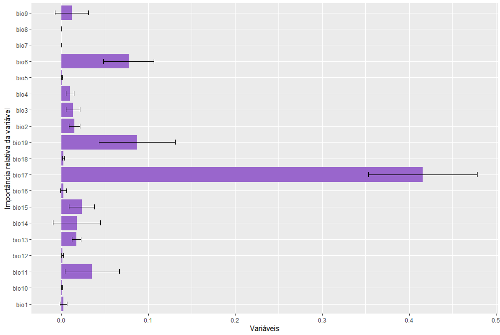

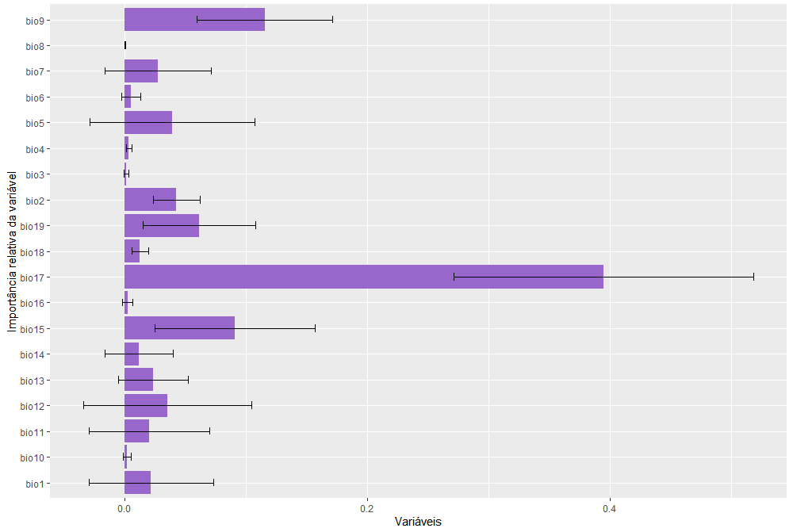

Importância relativa das variáveis para o modelo cheio da espécie de planta (acima) e para o morcego (abaixo)

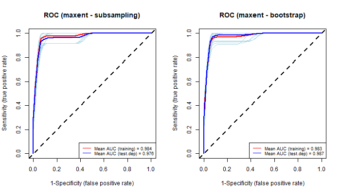

Valores médio de AUC para os 25 modelos gerados para a espécie *Encholirium subsecundum* com replicação por *subsampling* (à esquerda) e 25 por *bootstrap* (à direita)

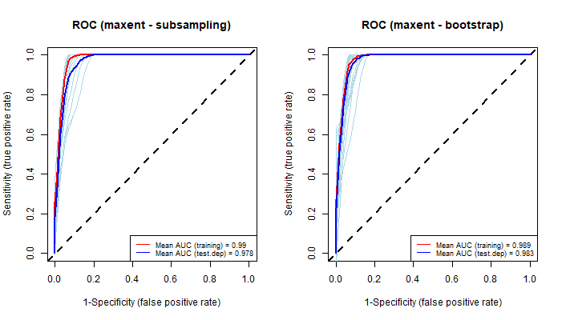

Valores médio de AUC para os 25 modelos gerados para a espécie *Lonchophylla bokermanni* com replicação por *subsampling* (à esquerda) e 25 por *bootstrap* (à direita)

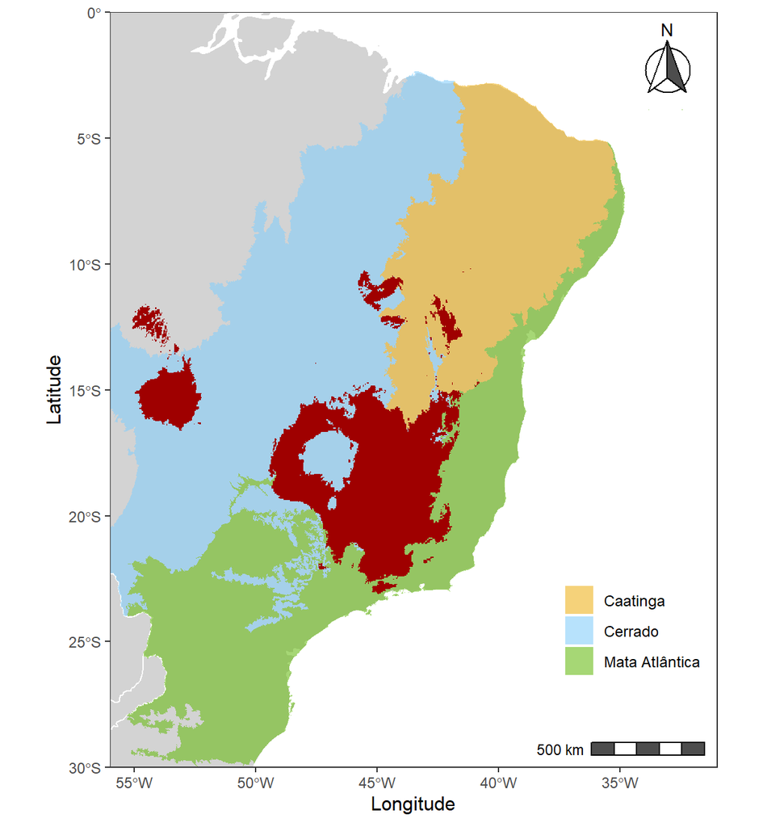

Distribuição potencial de *Encholirium subsecundum* (em vermelho) para o presente.

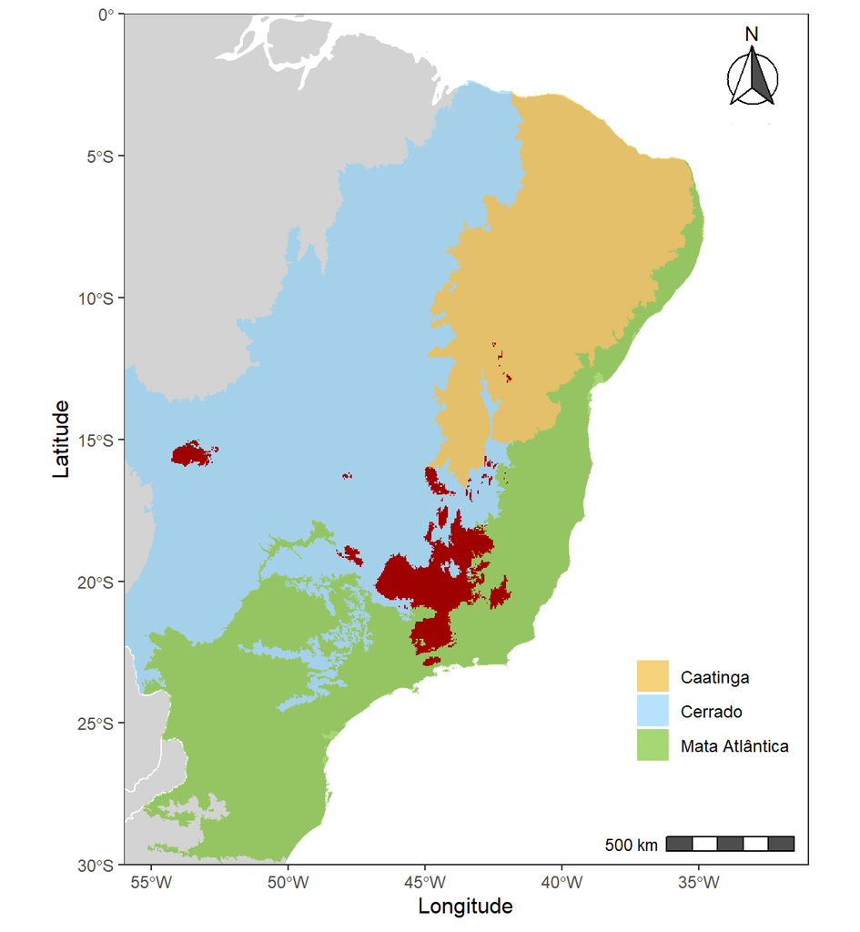

Distribuição potencial de *Encholirium subsecundum* (em vermelho) para o cenário futuro de RCP 4.5 (2050).

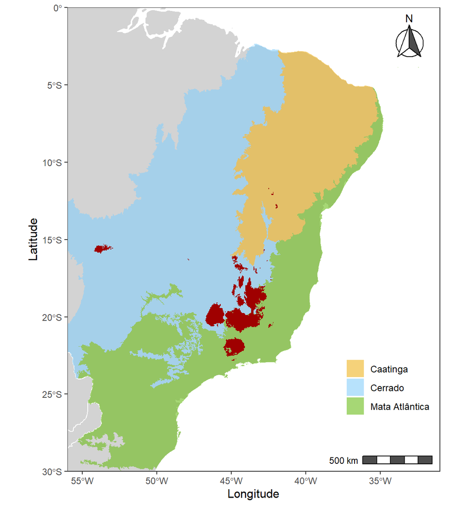

Distribuição potencial de *Encholirium subsecundum* (em vermelho) para o cenário futuro de RCP 8.5 (2050).

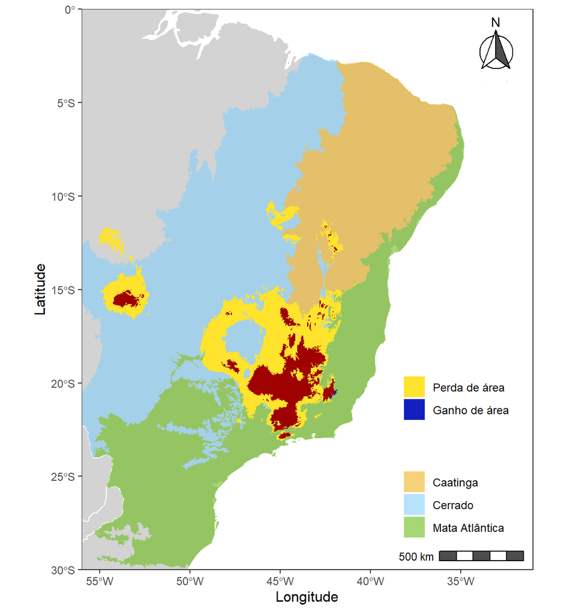

Mapa de alteração da distribuição potencial de *Encholirium subsecundum* no cenário RCP 4.5 (2050) em relação à distribuição do presente. A área em vermelho, amarelo e azul representam a distribuição sem alteração, perdida e ganha, respectivamente.

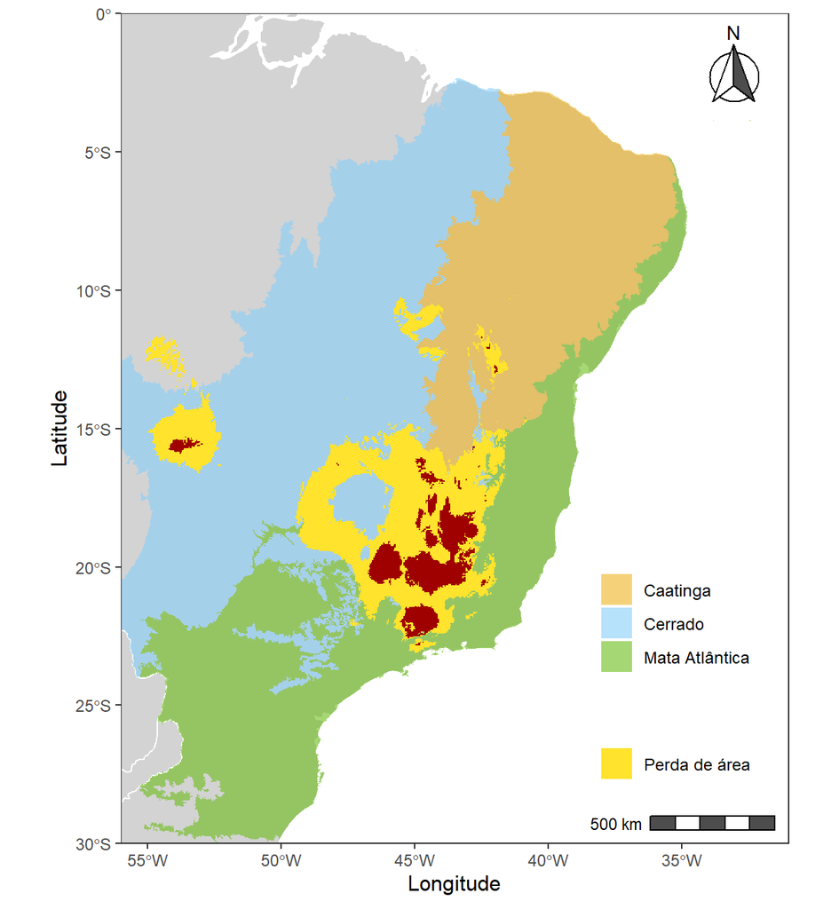

Mapa de alteração da distribuição potencial de *Encholirium subsecundum* no cenário RCP 8.5 (2050) em relação à distribuição do presente. A área em vermelho e amarelo representam a distribuição sem alteração e perdida. Não houve distribuição ganha da planta no RCP 8.5.

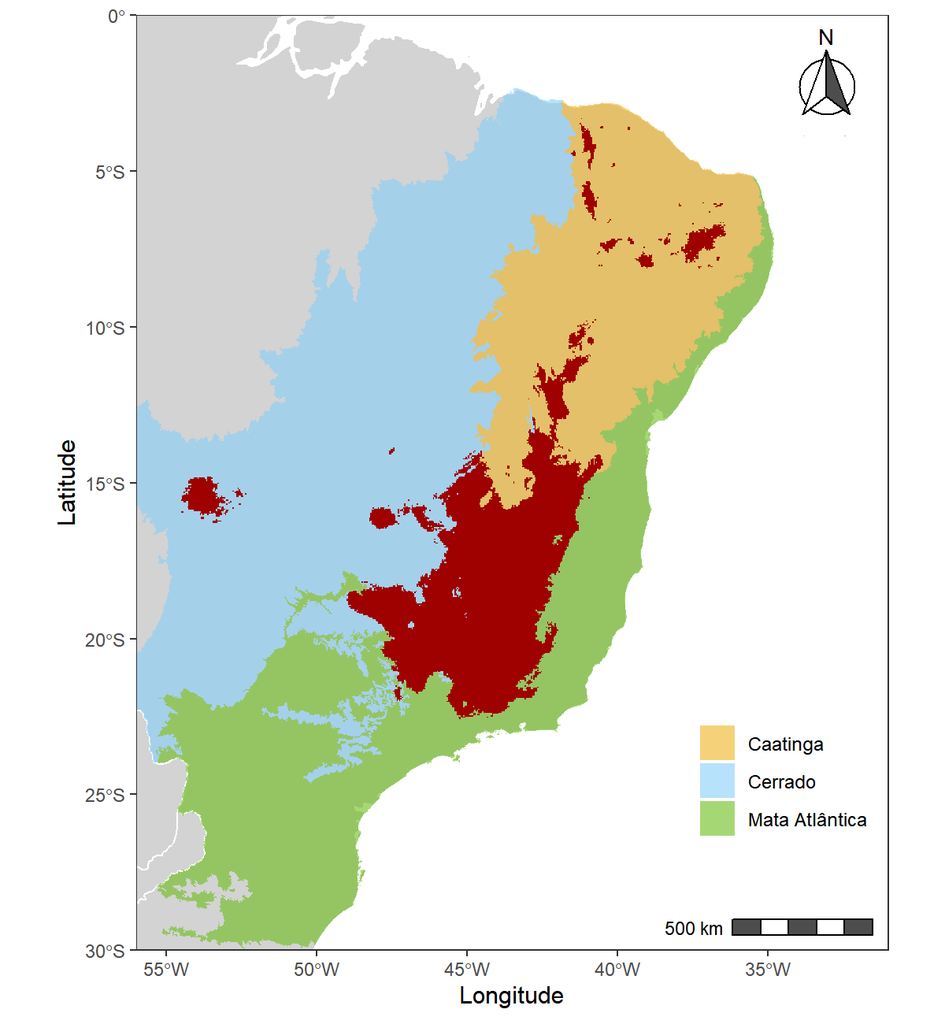

Distribuição potencial de *Lonchophylla bokermanni* (em vermelho) para o presente.

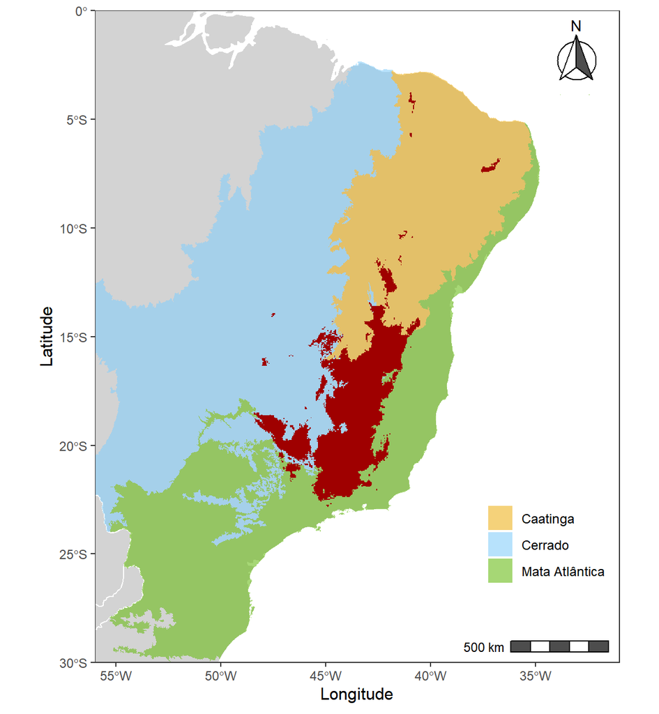

Distribuição potencial de *Lonchophylla bokermanni* (em vermelho) para o cenário futuro de RCP 4.5.

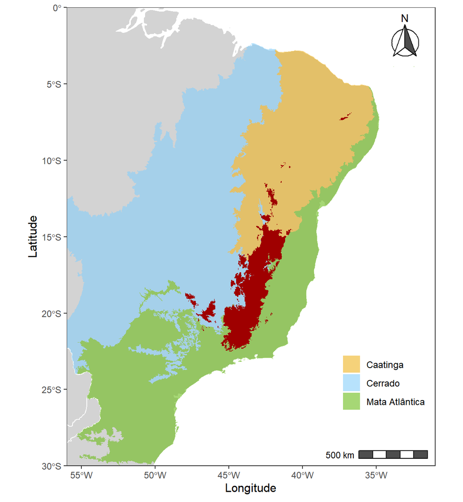

Distribuição potencial de *Lonchophylla bokermanni* (em vermelho) para o cenário futuro de RCP 8.5.

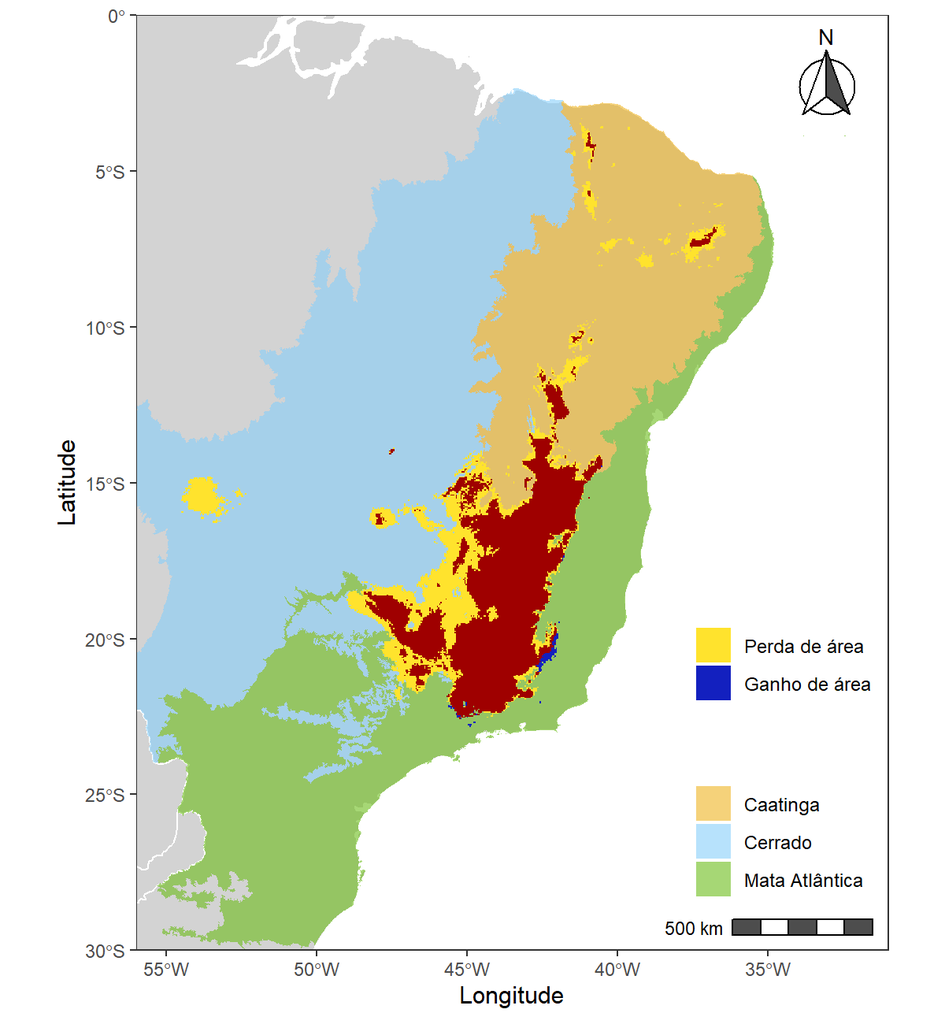

Mapa de alteração da distribuição potencial de *Lonchophylla bokermanni* no cenário RCP 4.5 (2050) em relação à distribuição do presente. A área em vermelho, amarelo e azul representam a distribuição sem alteração, perdida e ganha, respectivamente.

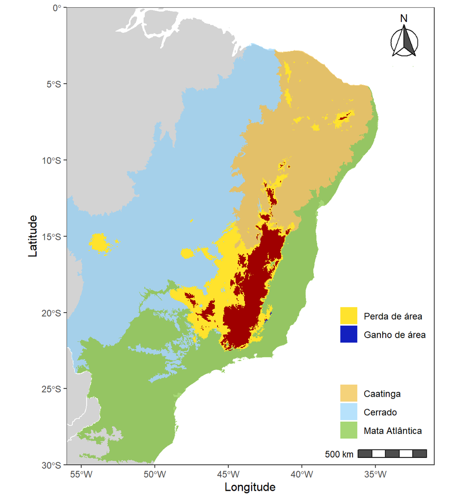

Mapa de alteração da distribuição potencial de *Lonchophylla bokermanni* no cenário RCP 8.5 (2050) em relação à distribuição do presente. A área em vermelho, amarelo e azul representam a distribuição sem alteração, perdida e ganha, respectivamente.

```r
############## SCRIPTS DO PROJETO DE PDPD ##############

# 1. Carregamento e corte das camadas ambientais do presente
# 2. Rodagem dos modelos de distribuicao para a especie
#    de planta Encholirium subsecundum e selecao das camadas
# 3. Rodagem do modelo final com as camadas selecionadas
# 4. Criacao das projecoes no presente
# 5. Criacao das projecoes no cenario futuro de RCP 4.5
# 6. Criacao das projecoes no cenario futuro de RCP 8.5
# 7. Construcao dos mapas simples, binarios e não binarios
# 7. Classificacao das alteracoes de area

################################################################################

##### Carregamento das bibliotecas necessarias
if (!require(tidyverse)) install.packages('tidyverse')
if (!require(sdm)) install.packages('sdm')
if (!require(dismo)) install.packages('dismo')
if (!require(dplyr)) install.packages('dplyr')
if (!require(mapview)) install.packages('mapview')
if (!require(raster)) install.packages('raster')
if (!require(rgdal)) install.packages('rgdal')
if (!require(usdm)) install.packages('usdm')

# Rodar na primeira vez para instalar as dependencias que o 'sdm' precisa.
installAll()

################################################################################
#--------- 1. CARREGAMENTO E CORTE DAS CAMADAS
#           AMBIENTAIS E DADOS DE E. SUBSECUNDUM  ---------#

### CARREGAR DADOS DE E. SUBSECUNUDUM
spg <- read.csv('./Dados/Ocorrencias/E_subsecundum_corrigido.csv')

# Adicionamos uma coluna com a especie (necesaria como argumento na modelagem)
spg$species <- 1

# Exploramos o data frame
head(spg)

# Transformar as coordenadas em um objeto "Spatial"
sp::coordinates(spg) <-c('x','y')
spg

#----------
### CARREGAR CAMADAS DO PRESENTE

# Criar um objeto com o contorno (poligono) do Brasil
mascara <- raster::shapefile('Dados/Mascaras/mascara_brasil.shp')

# Baixar camadas presente do database online Worldclim
bio <- raster::getData('worldclim', var='bio',res=2.5, path="./Camadas_presente/")
plot(bio)

# cortar as camadas com o shape do brasil
corte <- bio
cam_rep <- bio[[1]]

# Reduzir o tamanho da camada representante para um retangulo
cam_rep <- raster::crop(cam_rep, extent(mascara))

# Reduzir o tamanho de todas as camadas ambientais do presente
bioCams <- raster::resample(corte, cam_rep, method="bilinear",
                            snap='out', bylayer=TRUE, progress='text')

# Cortar as camadas ambientais e cortar a partir da mascara criada
bioCams <- raster::mask(bioCams, mascara, bylayer=TRUE)

# Verificacao
plot(bioCams)

#----------
### CARREGAR CAMADAS DO FUTURO RCP45, ANO 2050

# Donwload das camadas futuras (RCP 45) do database online Worldclim
biof45 <- raster::getData('CMIP5', var='bio', res=2.5, rcp=45, model='CN',
                          year=50, path="./Camadas_RCP45/")
plot(biof45)

# As camadas futuras devem ter o mesmo nome que as do presente
names(biof45) <- names(bio)

# Carregar as camadas e uma camada representante (bio 1) para corte das camadas
cortef <- biof45
cam_repf <- biof45[[1]]

# Reduzir o tamanho da camada representante para um retangulo
cam_repf <- raster::crop(cam_repf, extent(mascara))

# Reduzir o tamanho de todas as camadas ambientais RCP 45
bio45 <- raster::resample(cortef, cam_repf, method="bilinear",
                          snap='out', bylayer=TRUE, progress='text')

# Cortar as camadas ambientais e cortar a partir da mascara criada do Brasil
bio45 <- raster::mask(bio45, mascara, bylayer=TRUE)

# Verificacao
plot(bio45)

#----------
### CARREGAR CAMADAS DO FUTURO RCP85, ANO 2050

# Donwload das camadas futuras (RCP 45) do database online Worldclim
biof85 <- raster::getData('CMIP5', var='bio', res=2.5, rcp=85, model='CN',
                          year=50, path="./Camadas_RCP85/")
plot(biof85)

# As camadas futuras devem ter o mesmo nome que as do presente
names(biof85) <- names(bio)

# Carregar as camadas e uma camada representante (bio 1) para corte das camadas
cortef85 <- biof85
cam_repf85 <- biof85[[1]]

# Reduzir o tamanho da camada representante para um retangulo
cam_repf85 <- raster::crop(cam_repf85, extent(mascara))

# Reduzir o tamanho de todas as camadas ambientais RCP 85
bio85 <- raster::resample(cortef85, cam_repf85, method="bilinear",
                          snap='out', bylayer=TRUE, progress='text')

# Cortar as camadas ambientais e cortar a partir da mascara criada do Brasil
bio85 <- raster::mask(bio85, mascara, bylayer=TRUE)

# Verificacao
plot(bio85)

################################################################################
#--------- 2. RODAGEM DO MODELO PREVIO E
#               SELECAO DAS VARIAVEIS   ---------#

# MODELO CHEIO

# Adicionar os dados previo para fazer um modelo com todas as variaveis
dC <- sdm::sdmData(species~., spg, predictors = bioCams,
                   bg=list(method='gRandom', n=10000))
dC

# Ajustar e criar os modelos
mC <- sdm::sdm(species~., dC, methods = 'maxent', replication=c('sub', 'boot'),
               test.p=30, n=25, parallelSettings=list(ncore=5, method='parallel'))

# NOTAS: 1) Para o MaxEnt funcionar o Java do computador deve estar atualizado.
# 2) O parametro ncore e a quantidade de cores de processamento utilizados para
# a modelagem, altere conforme a capacidade do computador

mC

# Plot da importancia das variaveis
plot(getVarImp(mC), 'AUC', main="Importância relativa das biovariáveis",
     ylab='Variáveis', xlab="Importância relativa da variável") # Biovars: 6, 17, 19, 14
getVarImp(mC)

# Para abrir uma interface de exploracao do modelo
sdm::gui(mC)

#----------
# TESTE VIF COM AS VARIAVEIS COM MAIOR IMPORTANCIA

# Tiramos a camada 14 (alto vif e importância menor do que a correlata 17)
bioc <- raster::subset(bioCams, c(6, 17, 19))
vif(bioc)

# Essa parte ? desnecessaria pois ja fizemos de forma manual
# ex <- raster::extract(bioc,spg)
# head(ex)

# v <- usdm::vifstep(ex)
# cor(ex)

# Deixar apenas as vars sem problema de colinearidade
# bioc <- usdm::exclude(bioc, v)
# bioc

################################################################################
#--------- 3. MODELAGEM COM AS CAMADAS SELECIONADAS
#                    NA SECAO ANTERIOR   ---------#
```

```r
# Adicionar os dados previos: ocorrencias, camadas e pontos de background
d <- sdm::sdmData(species~., spg, predictors = bioc, bg=list(method='gRandom',
                                                             n=10000))
d

# Ajustar os modelos, 50 replicacoes, 25 por Subsampling e 25 por Bootstrap
m <- sdm::sdm(species~., d, methods='maxent', replication=c('sub', 'boot'),
              test.p=30, n=25, parallelSettings=list(ncore=5, method='parallel'))

# NOTAS: Como mencionado no item 2, o parametro ncore é a quantidade de cores de
# processamento utilizados para a modelagem, altere conforme a configuracao do
# computador

m

# Plot das contribuicoes das variaveis
plot(getVarImp(m), 'AUC')
sdm::getVarImp((m))

# Para abrir uma interface de exploracao do modelo
sdm::gui(m)

################################################################################
#--------- 4. PROJECAO DO MODELO PARA O PRESENTE   ---------#

# Projecao dos 50 modelos criados na seção anterior para o presente
p1 <- predict(m, bioc, filename='./Resultados_subsecundum/presente.img',
              overwrite=TRUE)
p1

# Obter um modelo consenso dentre os 50 criados para o presente por meio da
# mediana ponderada
en <- sdm::ensemble(m, bioc, filename =
                        './Resultados_subsecundum/ensemble_presente.img',
                    setting =list(method='weighted', stat='tss', opt=2),
                    overwrite=TRUE)
en

# Verificacao
plot(p1)
plot(en)

################################################################################
#--------- 5. PROJECAO DO MODELO PARA O FUTURO (RCP45)   ---------#

# Selecionar apenas as biovariaveis 6, 17, 19
bioS45 <- raster::subset(bio45, c(6, 17, 19))
plot(bioS45)

# Predicao utilizando o modelo criado na secao 3 para as camadas de RCP45
p2 <- predict(m, bioS45, filename='./Resultados_subsecundum/modelos_RCP45.img',
              overwrite=TRUE)
p2

# Obter um modelo consenso dentre os 50 criados para o futuro RCP45 por meio da
# mediana ponderada
en45 <- sdm::ensemble(m, bioS45, filename='./Resultados_subsecundum/futuro_RCP45.img',
                      setting =list(method='weighted', stat='tss', opt=2),
                      overwrite=TRUE)
en45

# Verificacao
plot(p2)
plot(en45)

################################################################################
#--------- 6. PROJECAO DO MODELO PARA O FUTURO (RCP85)   ---------#

# Selecionar apenas as biovariaveis 6, 17, 19
bioS85 <- raster::subset(bio85, c(6, 17, 19))
plot(bioS85)

# Predicao utilizando o modelo criado na secao 3 para as camadas de RCP85
p3 <- predict(m, bioS85, filename='./Resultados_subsecundum/modelos_RC85.img',
              overwrite=TRUE)
p3

# Obter um modelo consenso dentre os 50 criados para o futuro RCP85 por meio da
# mediana ponderada
en85 <- sdm::ensemble(m, bioS85, filename='./Resultados_subsecundum/futuro_RC85.img',
                      setting =list(method='weighted', stat='tss', opt=2),
                      overwrite=TRUE)

# Verificacao
plot(en85)

################################################################################
#--------- 7. CONSTRUCAO DE MAPAS BINARIOS E
#             DE DENSIDADE DE PROBABILIDADE  ---------#

# Paleta de cores
cores <- grDevices::colorRampPalette(c(
    '#3E49BB', '#3498DB', 'yellow', 'orange', 'red', 'darkred'))

# Plot dos mapa com a nova paleta de cores
plot(en, col=cores(200))
plot(en45, col=cores(200))
plot(en85, col=cores(200))

# Visualizacao alteranativa dos mapaP45 por meio do mapview
mapview::mapview(stack(en,en45,en85))

#----------
### Mapa de alteracao de adequabilidade (NAO BINARIO) entre o presente e o futuro
# de RCP 45
ch45 <- en45 - en

cores2<-grDevices::colorRampPalette(c('red', 'orange', 'yellow', 'gray',
                                      'green', 'blue'))
plot(ch45, col=cores2(200))
# Areas mais proximas ao azul representam areas ganhas no futuro (RCP45)
# Areas mais proximas ao vermelho representam areas ganhas perdidas (RCP45)
# Areas cinzas permanceram inalteradas no futuro

#----------
### Mapa de alteracao de adequabilidade (NAO BINARIO) entre o presente e o futuro
# de RCP 85
ch85 <- en85 - en

cores2<-grDevices::colorRampPalette(c('red', 'orange', 'yellow', 'gray',
                                      'green', 'blue'))
plot(ch85, col=cores2(200))

#----------
### OBTER MEDIDAS DE THRESHOLD PARA A CONSTRUCAO DOS mapaP45 BINARIOS
df <- as.data.frame(d)
df <- data.frame(species=df$species, coordinates(d))
xy = as.matrix(df[,c('x', 'y')])
head(xy)

# Extrair do raster da predicao do presente os valores das biovariaveis nos
# pontos de ocorrencias das especies
p<-raster::extract(en,xy)

# Avaliacao do modelo
ev <- evaluates(df$species,p)
ev@statistics

# Medidadas de threshold
ev@threshold_based

th <- ev@threshold_based$threshold[2] #Threshold pelo metodo SSS: max(espec+sens)

# Verificar valor de threshold
th

#----------
### MAPA BINARIO DO PRESENTE UTILIZANDO O VALOR DE THRESHOLD th
pa1 <- raster(en)
pa1[] <- ifelse(en[] >= th, 1,0)
plot(pa1)

### MAPA BINARIO DO FUTURO (RCP45)
pa2 <- raster(en45)
pa2[] <- ifelse(en45[] >= th, 1,0)
plot(pa2)

### MAPA BINARIO DO FUTURO (RCP85)
pa3 <- raster(en85)
pa3[] <- ifelse(en85[] >= th, 1,0)
plot(pa3)

### MAPA BINARIO DE ALTERACAO DE ADEQUABILIDADE (Futuro RCP45 - Presente)
chp45 <- pa2 - pa1
plot(chp45, col=c('red','gray','blue'))

### MAPA BINARIO DE ALTERACAO DE ADEQUABILIDADE (Futuro RCP85 - Presente)
chp85 <- pa3 - pa1
plot(chp85, col=c('red','gray', 'blue'))

################################################################################
#--------- 7. CLASSIFICACAO DAS ALTERACOES DE AREA   ---------#

# Obter os tamanhos das celulas
cel_tam<-area(pa1, na.rm=TRUE, weights=FALSE)
cel_tam<-cel_tam[!is.na(cel_tam)]

#----------
### AREA PRESENTE  (KM^2)
mapa <- pa1$layer@data@values==1
tamanho <- sum(mapa[!is.na(mapa)])
area <- tamanho*median(cel_tam)
area

#----------
###  AREA FUTURA (RCP45)  (KM^2)
mapaF45 <- pa2$layer@data@values==1
tamanhoF45 <- sum(mapaF45[!is.na(mapaF45)])
areaF45 <- tamanhoF45*median(cel_tam)
areaF45
```

```r
#----------
###  AREA FUTURA (RCP85)  (KM^2)
mapaF85 <- pa3$layer@data@values==1
tamanhoF85 <- sum(mapaF85[!is.na(mapaF85)])
areaF85 <- tamanhoF85*median(cel_tam)
areaF85

#----------
###  AREA ALTERADA ENTRE O PRESENTE E O FUTURO RCP45 (KM^2)
# area de perda < 0
# area de ganho > 0

mapaP45 <- chp45$layer@data@values < 0
tamanhoP45 <- sum(mapaP45[!is.na(mapaP45)])
areaP45 <- tamanhoP45*median(cel_tam)
areaP45        # Area perdida

# Porcentagem de perda
(areaP45/area)*100


mapaG45 <- chp45$layer@data@values >0
tamanhoG45 <- sum(mapaG45[!is.na(mapaG45)])
areaG45 <- tamanhoG45*median(cel_tam)
areaG45        # Area ganha

# Porcentagem de ganho
(areaG45/area)*100

#----------
###  AREA ALTERADA ENTRE O PRESENTE E O FUTURO RCP85 (KM^2)
# area de perda < 0
# area de ganho > 0

mapaP85 <- chp85$layer@data@values < 0
tamanhoP85 <- sum(mapaP85[!is.na(mapaP85)])
areaP85 <- tamanhoP85*median(cel_tam)
areaP85        # Area perdida

# Porcentagem de perda
(areaP85/area)*100


mapaG85 <- chp85$layer@data@values >0
tamanhoG85 <- sum(mapaG85[!is.na(mapaG85)])
areaG85 <- tamanhoG85*median(cel_tam)
areaG85        # Area ganha

# Porcentagem de ganho
(areaG85/area)*100
```